# Flows

Exploring flows visually and through spatial interaction

Dani Arribas-Bel

2017-03-14

This note is part of Spatial Analysis Notes  
Flows – Exploring flows visually and through spatial interaction by [Dani Arribas-Bel](http://darribas.org) is licensed under a [Creative Commons Attribution-NonCommercial-ShareAlike 4.0 International License](http://creativecommons.org/licenses/by-nc-sa/4.0/).

Content is based on the following references, which are great follow-up’s on the topic:

- Singleton (2017), an online short course on R for Geographic Data Science and Urban Analytics. In particular, the section on [mapping flows](https://github.com/alexsingleton/GDS_UA_2017/tree/master/Mapping_Flows) is specially relevant here.

  Singleton, Alex. 2017. “Geographic Data Science for Urban Analytics.” http://www.alex-singleton.com/GDS_UA_2017/.
- The predictive checks section draws heavily from Gelman and Hill (2006), in particular Chapters 6 and 7.

  Gelman, Andrew, and Jennifer Hill. 2006. *Data Analysis Using Regression and Multilevel/Hierarchical Models*. Cambridge University Press.

This tutorial is part of Spatial Analysis Notes, a compilation hosted as a GitHub repository that you can access in a few ways:

- As a [download](https://github.com/darribas/spa_notes/archive/master.zip) of a `.zip` file that contains all the materials.
- As an [html website](http://darribas.org/spa_notes/flows.html).
- As a [pdf document](https://github.com/darribas/spa_notes/raw/master/flows_book.pdf)
- As a [GitHub repository](https://github.com/darribas/spa_notes).

# Dependencies

This tutorial relies on the following libraries that you will need to have installed on your machine to be able to interactively follow along. Once installed, load them up with the following commands:

You can install package `mypackage` by running the command `install.packages("mypackage")` on the R prompt or through the `Tools --> Install Packages...` menu in RStudio.

```r
# Layout
library(tufte)
# Spatial Data management
library(rgdal)
```

```r
# Pretty graphics
library(ggplot2)
# Thematic maps
library(tmap)
# Pretty maps
library(ggmap)
# Simulation methods
library(arm)
```

Before we start any analysis, let us set the path to the directory where we are working. We can easily do that with `setwd()`. Please replace in the following line the path to the folder where you have placed this file -and where the `sf_bikes` folder with the data lives.

```r
#setwd('/media/dani/baul/AAA/Documents/teaching/u-lvl/2016/envs453/code')
setwd('.')
```

# Data

In this note, we will use data from the city of San Francisco representing bike trips on their public bike share system. The original source is the SF Open Data portal ([link](http://www.bayareabikeshare.com/open-data)) and the dataset comprises both the location of each station in the Bay Area as well as information on trips (station of origin to station of destination) undertaken in the system from September 2015 to August 2016. Since this note is about modeling and not data preparation, a cleanly reshaped version of the data, together with some additional information, has been created and placed in the `sf_bikes` folder. The data file is named `flows.geojson` and, in case you are interested, the (Python) code required to created from the original files in the SF Data Portal is also available on the `flows_prep.ipynb` notebook [[url]](https://github.com/darribas/spa_notes/blob/master/sf_bikes/flows_prep.ipynb), also in the same folder.

Let us then directly load the file with all the information necessary:

```r
db <- readOGR(dsn='sf_bikes/flows.geojson', layer='OGRGeoJSON')
```

Note how the interface is slightly different since we are reading a `GeoJSON` file instead of a shapefile.

The data contains the geometries of the flows, as calculated from the [Google Maps API](https://developers.google.com/maps/), as well as a series of columns with characteristics of each flow:

```r
head(db@data)
```

```
##   orig dest street_dist straight_dist total_down total_up trips
## 0   39   41   1804.1150      1452.201  11.205753 4.698162    68
## 1   39   42   2069.1557      1734.861  10.290236 2.897886    29
## 2   39   45   1747.9928      1255.349  11.015596 4.593927    50
## 3   39   46   1490.8361      1323.303   3.511543 5.038044   163
## 4   39   47    769.9189       715.689   0.000000 3.282495    73
## 5   39   48   2740.1290      1996.778  11.375186 3.841296    56
```

where `orig` and `dest` are the station IDs of the origin and destination, `street/straight_dist` is the distance in metres between stations measured along the street network or as-the-crow-flies, `total_down/up` is the total downhil and climb in the trip, and `trips` contains the amount of trips undertaken in the period of study.

# “*Seeing*” flows

The easiest way to get a quick preview of what the data looks like spatially is to make a simple plot:

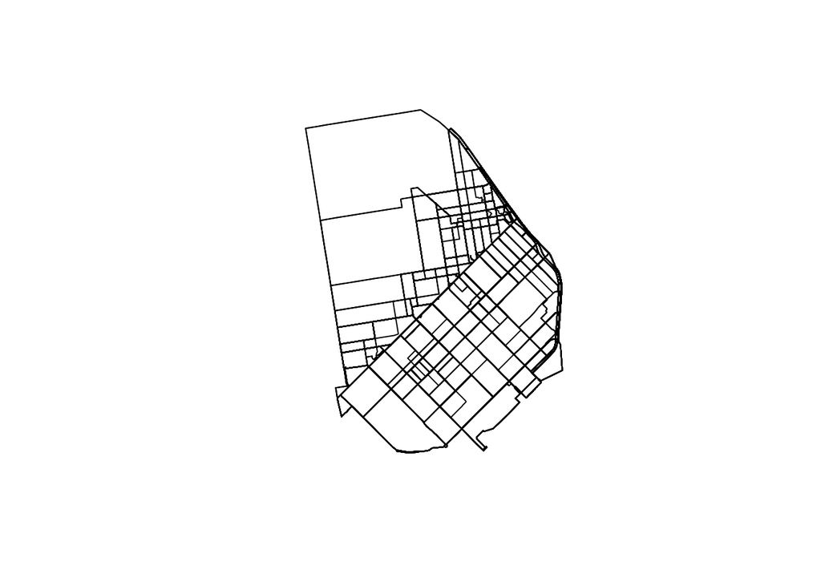

Potential routes

```r
plot(db)
```

Equally, if we want to visualize a single route, we can simply subset the table. For example, to get the shape of the trip from station `39` to station `48`, we can:

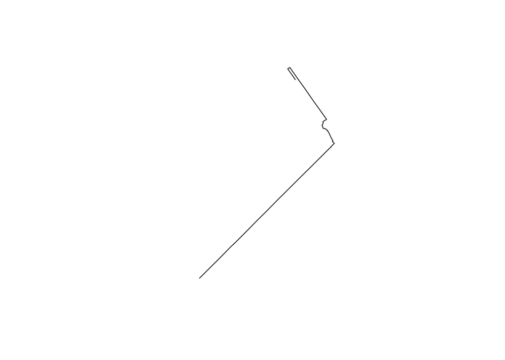

Trip from station 39 to 48

```r
one39to48 <- db[ which(
          db@data$orig == 39 & db@data$dest == 48
          ) , ]
plot(one39to48)
```

or, for the most popular route, we can:

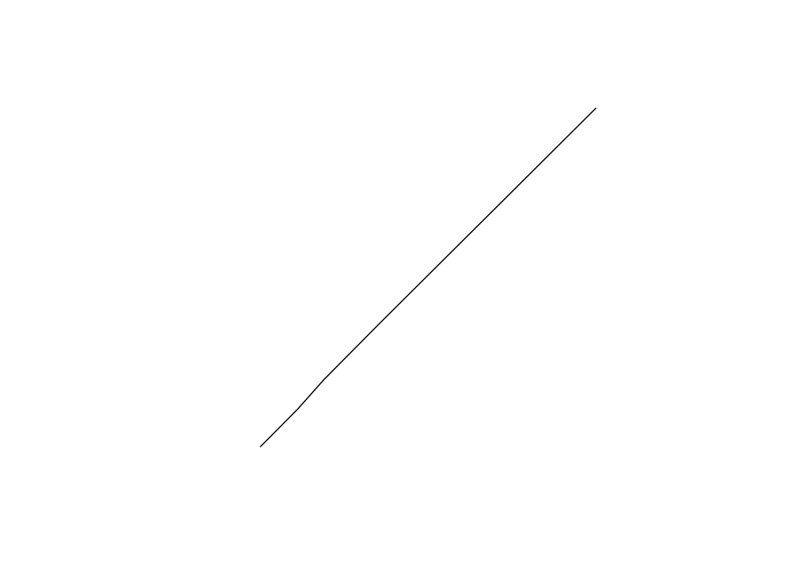

Most popular trip

```r
most_pop <- db[ which(
          db@data$trips == max(db@data$trips)
          ) , ]
plot(most_pop)
```

These however do not reveal a lot: there is no geographical context (*why are there so many routes along the NE?*) and no sense of how volumes of bikers are allocated along different routes. Let us fix those two.

The easiest way to bring in geographical context is by overlaying the routes on top of a background map of tiles downloaded from the internet. Let us download this using `ggmap`:

```r
sf_bb <- c(left=db@bbox['x', 'min'],
           right=db@bbox['x', 'max'],
           bottom=db@bbox['y', 'min'],
           top=db@bbox['y', 'max'])
SanFran <- get_stamenmap(sf_bb,
                         zoom = 14,
                         maptype = "toner-lite")
```

and make sure it looks like we intend it to look:

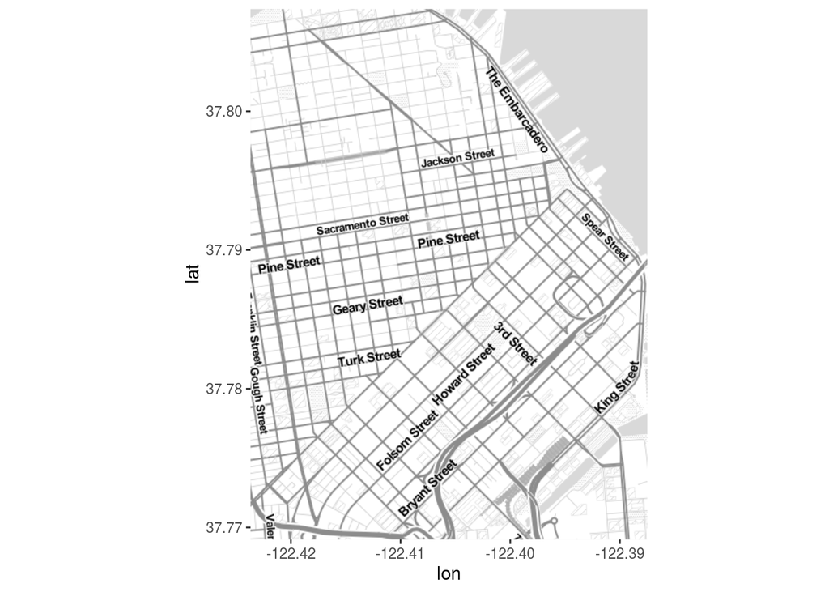

```r
ggmap(SanFran)
```

Now to combine tiles and routes, we need to pull out the coordinates that make up each line. For the route example above, this would be:

```r
xys1 <- as.data.frame(coordinates(most_pop))
```

Now we can plot the route (note we also dim down the background to focus the attention on flows):

**EXERCISE**: *can you plot the route for the largest climb?*

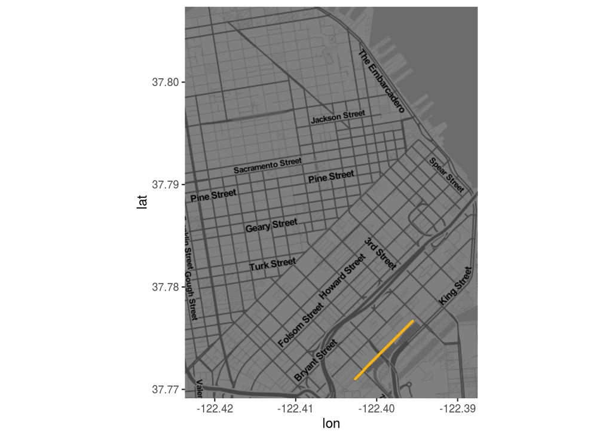

```r
ggmap(SanFran, darken=0.5) +
  geom_path(aes(x=X1, y=X2),
            data=xys1,
            size=1,
            color=rgb(0.996078431372549, 0.7019607843137254, 0.03137254901960784),
            lineend='round')
```

Now we can plot all of the lines by using a short `for` loop to build up the table:

```r
# Set up shell data.frame
lines <- data.frame(lat = numeric(0),
                    lon = numeric(0),
                    trips = numeric(0),
                    id = numeric(0)
                    )
# Run loop
for(x in 1:nrow(db)){
  # Pull out row
  r <- db[x, ]
  # Extract lon/lat coords
  xys <- as.data.frame(coordinates(r))
  names(xys) <- c('lon', 'lat')
  # Insert trips and id
  xys['trips'] <- r@data$trips
  xys['id'] <- x
  # Append them to `lines`
  lines <- rbind(lines, xys)
}
```

Now we can go on and plot all of them:

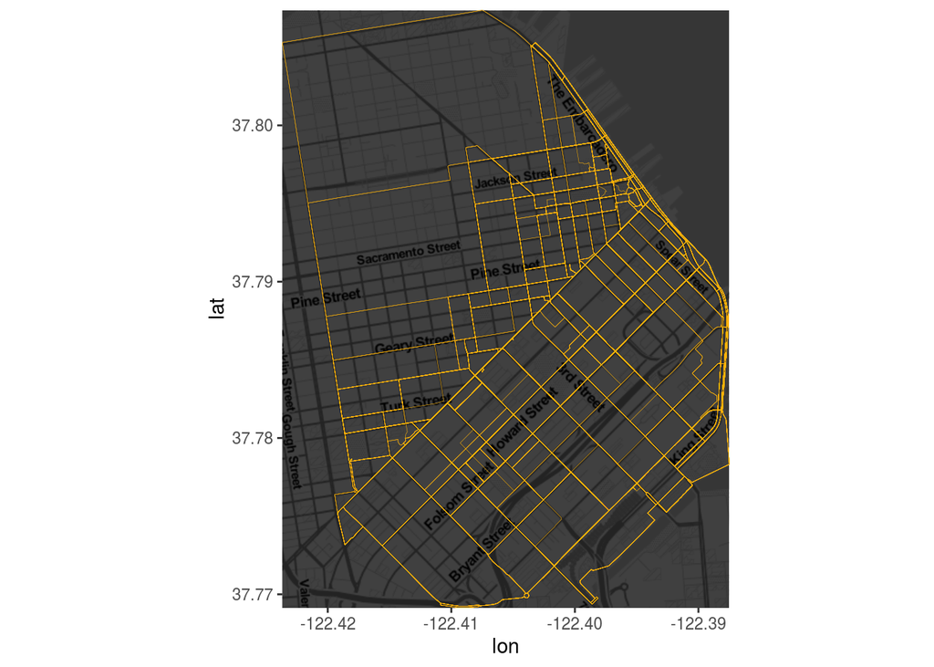

```r
ggmap(SanFran, darken=0.75) +
  geom_path(aes(
                x=lon,
                y=lat,
                group=id
                ),
            data=lines,
            size=0.1,
            color=rgb(0.996078431372549, 0.7019607843137254, 0.03137254901960784),
            lineend='round')
```

Finally, we can get a sense of the distribution of the flows by associating a color gradient to each flow based on its number of trips:

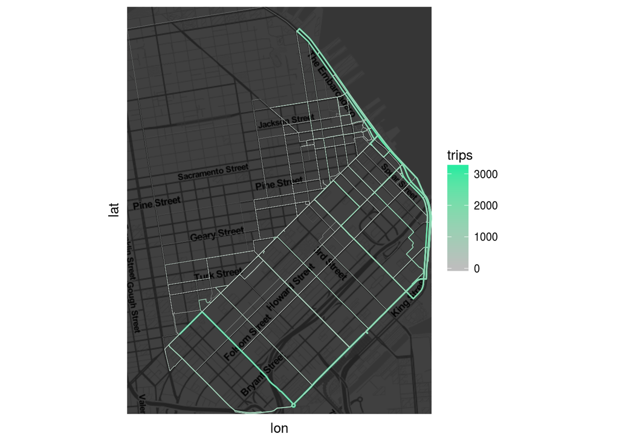

```r
ggmap(SanFran, darken=0.75) +
  geom_path(aes(
                x=lon,
                y=lat,
                group=id,
                colour=trips
                ),
            data=lines,
            size=log1p(lines$trips / max(lines$trips)),
            lineend='round') +
  scale_colour_gradient(low='grey',
                        high='#07eda0') +
  theme(axis.text.x = element_blank(),
      axis.text.y = element_blank(),
      axis.ticks = element_blank()
      )
```

Note how we transform the size so it’s a proportion of the largest trip and then it is compressed with a logarithm.

# Modelling flows

Now we have an idea of the spatial distribution of flows, we can begin to think about modeling them. The core idea in this section is to fit a model that can capture the particular characteristics of our variable of interest (the volume of trips) using a set of predictors that describe the nature of a given flow. We will start from the simplest model and then progressively build complexity until we get to a satisfying point. Along the way, we will be exploring each model using concepts from Gelman and Hill (2006) such as predictive performance checks (PPC)

Gelman, Andrew, and Jennifer Hill. 2006. *Data Analysis Using Regression and Multilevel/Hierarchical Models*. Cambridge University Press.

Before we start running regressions, let us first standardize the predictors so we can interpret the intercept as the average flow when all the predictors take the average value, and so we can interpret the model coefficients as changes in standard deviation units:

```r
# Scale all the table
db_std <- as.data.frame(scale(db@data))
# Reset trips as we want the original version
db_std$trips <- db@data$trips
# Reset origin and destination station and express them as factors
db_std$orig <- as.factor(db@data$orig)
db_std$dest <- as.factor(db@data$dest)
```

## Baseline model

One of the simplest possible models we can fit in this context is a linear model that explains the number of trips as a function of the straight distance between the two stations and total amount of climb and downhill. We will take this as the baseline on which we can further build later:

```r
m1 <- lm('trips ~ straight_dist + total_up + total_down', data=db_std)
summary(m1)
```

```
##
## Call:
## lm(formula = "trips ~ straight_dist + total_up + total_down",
##     data = db_std)
##
## Residuals:
##     Min      1Q  Median      3Q     Max
## -259.48 -152.50  -95.36   18.50 3148.09
##
## Coefficients:
##               Estimate Std. Error t value Pr(>|t|)
## (Intercept)    163.550      7.791  20.991  < 2e-16 ***
## straight_dist   24.847      8.751   2.839  0.00457 **
## total_up       -40.198      8.986  -4.473  8.2e-06 ***
## total_down     -19.612      8.867  -2.212  0.02711 *
## ---
## Signif. codes:  0 '***' 0.001 '**' 0.01 '*' 0.05 '.' 0.1 ' ' 1
##
## Residual standard error: 323.3 on 1718 degrees of freedom
## Multiple R-squared:  0.02004,    Adjusted R-squared:  0.01833
## F-statistic: 11.71 on 3 and 1718 DF,  p-value: 1.354e-07
```

To explore how good this model is, we will be comparing the predictions the model makes about the number of trips each flow should have with the actual number of trips. A first approach is to simply plot the distribution of both variables:

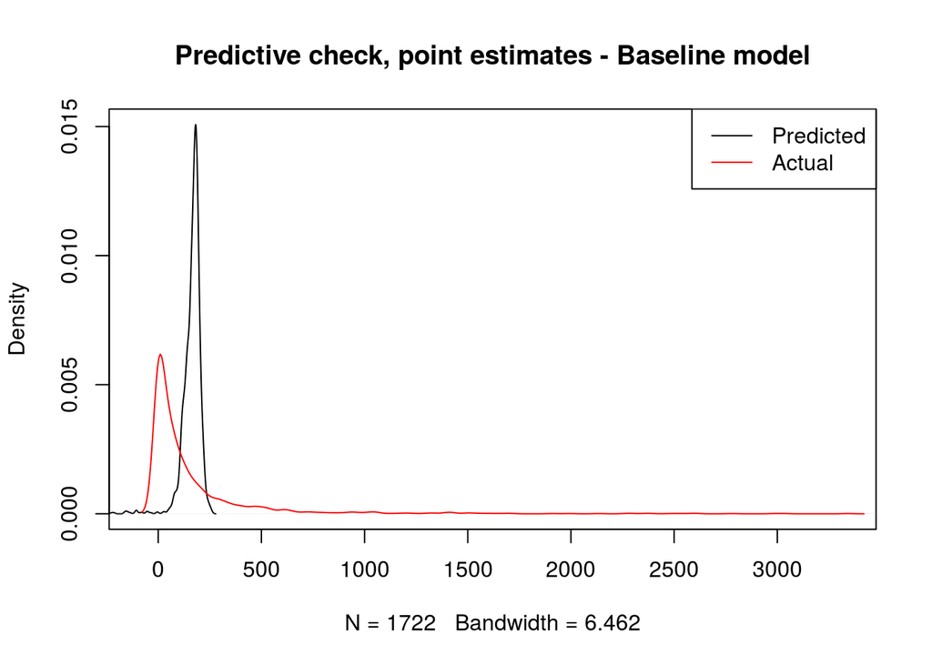

```r
plot(density(m1$fitted.values),
     xlim=c(-100, max(db_std$trips)),
     main='')
lines(density(db_std$trips),
      col='red',
      main='')
legend('topright',
       c('Predicted', 'Actual'),
       col=c('black', 'red'),
       lwd=1)
title(main="Predictive check, point estimates - Baseline model")
```

The plot makes pretty obvious that our initial model captures very few aspects of the distribution we want to explain. However, we should not get too attached to this plot just yet. What it is showing is the distribution of predicted *point* estimates from our model. Since our model is not deterministic but inferential, there is a certain degree of uncertainty attached to its predictions, and that is completely absent from this plot.

Generally speaking, a given model has two sources of uncertainty: *predictive*, and *inferential*. The former relates to the fact that the equation we fit does not capture all the elements or in the exact form they enter the true data generating process; the latter has to do with the fact that we never get to know the true value of the model parameters only guesses (estimates) subject to error and uncertainty. If you think of a linear model as

$$y = X\beta + \epsilon$$
predictive uncertainty comes from the fact that there are elements to some extent relevant for $y$ that are not accounted for and thus subsummed into $\epsilon$. Inferential uncertainty comes from the fact that we never get to know $\beta$ but only an estimate of it which is also subject to uncertainty itself.

Taking these two sources into consideration means that the black line in the plot above represents only the *expected* behaviour of our model. However, we do not know to what extent other outcomes would be just as likely. Predictive checking relates to simulate several perfectly possible scenarios from our model and use those to assess uncertainty and to get a better grasp of the quality of our predictions.

Technically speaking, to do this, we need to build a mechanism to obtain a possible draw from our model and then repeat it several times. The first part of those two steps can be elegantly dealt with by writing a short function that takes a given model and a set of predictors, and produces a possible random draw from such model:

```r
generate_draw <- function(m){
  # Set up predictors matrix
  x <- model.matrix(m)
  # Obtain draws of parameters (inferential uncertainty)
  sim_bs <- sim(m, 1)
  # Predicted value
  y_hat <- x %*% sim_bs@coef[1, ]
  return(y_hat)
}
```

This function takes a model `m` and the set of covariates `x` used and returns a random realization of predictions from the model. To get a sense of how this works, we can get and plot a realization of the model, compared to the expected one and the actual values:

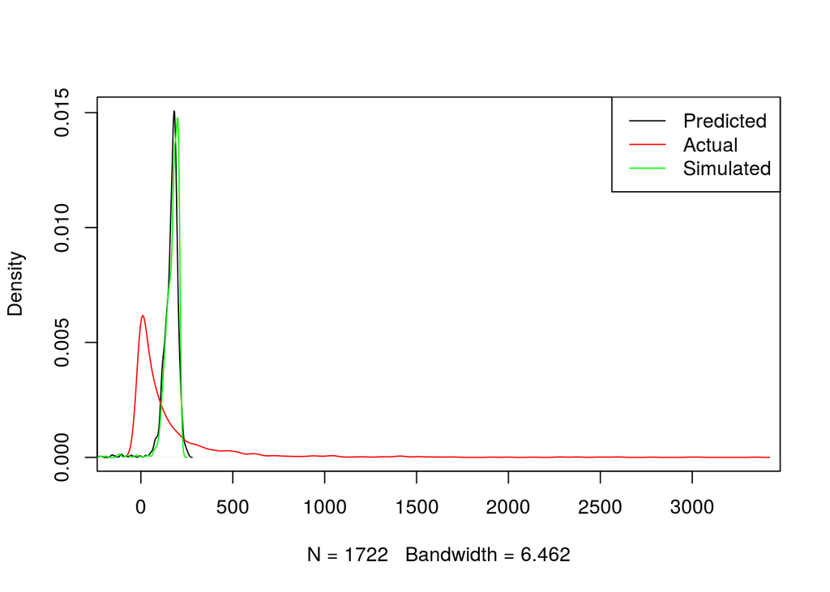

```r
new_y <- generate_draw(m1)

plot(density(m1$fitted.values),
     xlim=c(-100, max(db_std$trips)),
     ylim=c(0, max(c(
                      max(density(m1$fitted.values)$y),
                      max(density(db_std$trips)$y)
                      )
                   )
            ),
     col='black',
     main='')
lines(density(db_std$trips),
      col='red',
      main='')
lines(density(new_y),
      col='green',
      main='')
legend('topright',
       c('Predicted', 'Actual', 'Simulated'),
       col=c('black', 'red', 'green'),
       lwd=1)
```

Once we have this “draw engine”, we can set it to work as many times as we want using a simple `for` loop. In fact, we can directly plot these lines as compared to the expected one and the trip count:

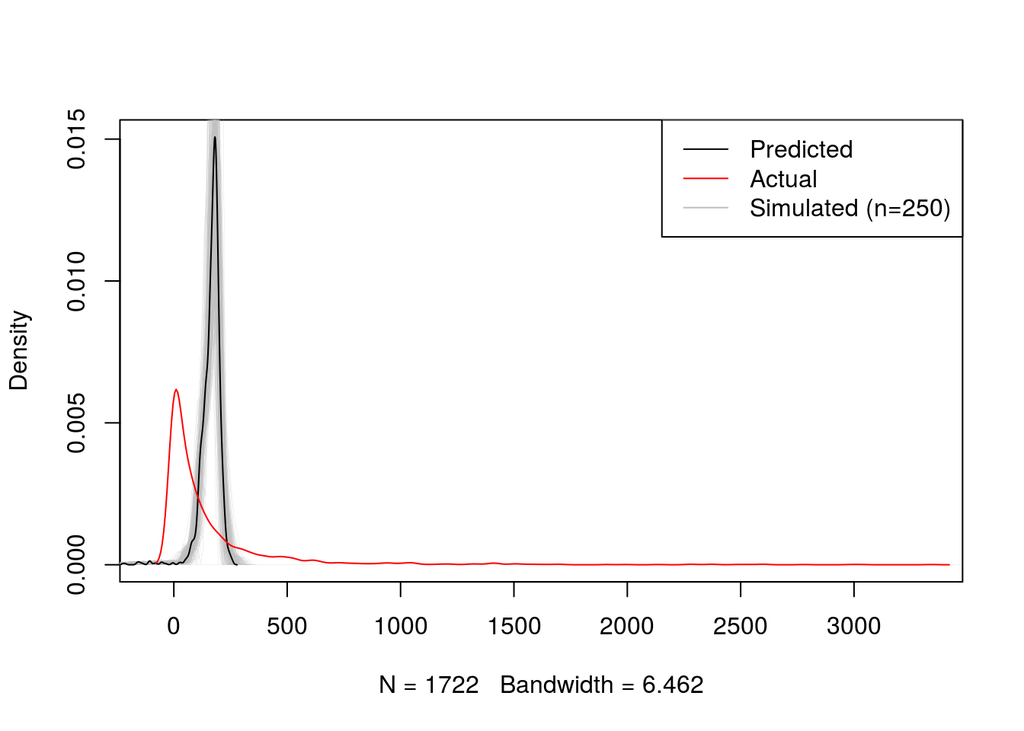

```r
plot(density(m1$fitted.values),
     xlim=c(-100, max(db_std$trips)),
     ylim=c(0, max(c(
                  max(density(m1$fitted.values)$y),
                  max(density(db_std$trips)$y)
                  )
               )
        ),
     col='white',
     main='')
# Loop for realizations
for(i in 1:250){
  tmp_y <- generate_draw(m1)
  lines(density(tmp_y),
        col='grey',
        lwd=0.1
        )
}
#
lines(density(m1$fitted.values),
      col='black',
      main='')
lines(density(db_std$trips),
      col='red',
      main='')
legend('topright',
       c('Predicted', 'Actual', 'Simulated (n=250)'),
       col=c('black', 'red', 'grey'),
       lwd=1)
```

The plot shows that there is an area around our expected predictions where our model could have also produced realistic predictions. However, this only brings additional nuance to out interpretation in this context. The bottomline is still our baseline model is pretty poor at predicting bike trips.

## Improving the model

The bad news from the previous section is that our initial model is not great at explaining bike trips. The good news is there are several ways in which we can improve this. In this section we will cover three main extensions that exemplify three different routes you can take when enriching and augmenting models in general, and spatial interaction ones in particular. These three routes are aligned around the following principles:

These principles are general and can be applied to pretty much any modeling exercise you run into. The specific approaches we take in this note relate to spatial interaction models

1. Recognize the structure of your data.
2. Use better approximations to model your dependent variable.
3. Get better predictors.

### Recognize the structure of your data

So far, we’ve treated our dataset as if it was flat (i.e. comprise of fully independent realizations) when in fact it is not. Most crucially, our baseline model does not account for the fact that every observation in the dataset pertains to a trip between two stations. This means that all the trips from or to the same station probably share elements which likely help explain how many trips are undertaken between stations. For example, think of trips to an from a station located in the famous Embarcadero, a popular tourist spot. Every route to and from there probably has more trips due to the popularity of the area and we are currently not acknowledging it in the model.

A simple way to incorporate these effects into the model is through origin and destination fixed effects. This approach shares elements with both spatial fixed effects and multilevel modeling and essentially consists of including a binary variable for every origin and destination station. This accounts for all the unobserved heterogeneity associated with the location of the station. Technically speaking, we simply need to introduce `orig` and `dest` in the the model:

```r
m2 <- lm('trips ~ straight_dist + total_up + total_down + orig + dest', data=db_std)
```

And with our new model, we can have a look at how well it does at predicting the overall number of trips:

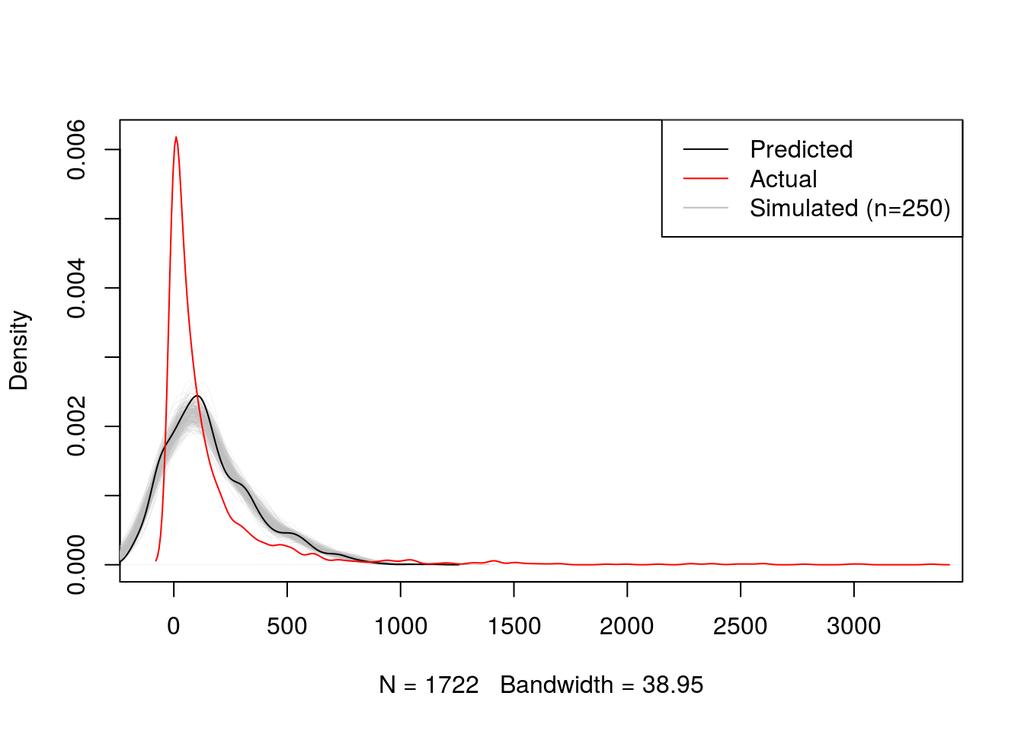

```r
plot(density(m2$fitted.values),
     xlim=c(-100, max(db_std$trips)),
     ylim=c(0, max(c(
                  max(density(m2$fitted.values)$y),
                  max(density(db_std$trips)$y)
                  )
               )
      ),
     col='white',
     main='')
# Loop for realizations
for(i in 1:250){
  tmp_y <- generate_draw(m2)
  lines(density(tmp_y),
        col='grey',
        lwd=0.1
        )
}
#
lines(density(m2$fitted.values),
      col='black',
      main='')
lines(density(db_std$trips),
      col='red',
      main='')
legend('topright',
       c('Predicted', 'Actual', 'Simulated (n=250)'),
       col=c('black', 'red', 'grey'),
       lwd=1)
```

# Predicting flows